```python
%%javascript
IPython.OutputArea.prototype._should_scroll = function(lines) {
    return false;
}
```

### Python, Jupyter Notebook, Image Rending, ipyplot

# Three methods to display grids of images inside jupyter notebook using Python

**Post Goals, Demonstrate how to display a grid of images in jupyter notebook using:**

1. IPython.display HTML and Image.
2. The ipyplot library
3. Matplotlib

**Motivation:**

- Jupyter notebook is a popular web-based interactive environment to display, share documents that contain code, equations, and visualizations.
- Displaying data visualizations using python libraries such as python, matplotlib, and seaborn is well documented, but there are many cases where displaying images can be helpful.
- Images can be added using from local files and a url, although most methods only allow you to display one image, in some cases you may want to display a grid of images. Grids allow you to compress your images in a well contained cell without having to provide multiple cells that take up space.
- The aim of this post is to demonstrate how to display a grid of images using a few common and well documented methods.

# Set up Variables for Filesystem path and Images

- The filepath to the images must be established before the they can be loaded using the methods described in this post.
- If the images are in the same directory as the jupyter notebook, then you will have less work.
- The following code demonstrates how to link to images in subdirectories.
- The two modules you will need are `os` and `pathlib`.
- The `os` modules provides a portable way of using operating system dependent functionality. We will use it here to get the current working directory and general file system manipulation.
- The `pathlib` module offers classes representing file system paths and semantics that work for different operating systems.

```python
# Import modules
import os
import os.path as path
from pathlib import Path
cwd = os.getcwd() # get current working directory
```

```python
# code that will display images using matplotlib
subdir = 'static/images/imread' # string that lists the relative subdirectory for matplotlib
rf_path = os.path.join(cwd, subdir) # use os and path to join cwd and the subdirectory, this create the filepath
files = os.listdir(rf_path) # use os module and listdir to get a list image files in your subdirectory
```

## Prepare a list of filepaths to images using a for loop and if statement

- this will return a relative path

```python
# this method uses a for loop to generate a list of relative filepaths with png only
images = []
for file in files:
    if file.endswith('png'):
        fpath = os.path.join(subdir, file)
        images.append(fpath)
```

# Display a grid of images using matplotlib

**matplotlib**

- Matplotlib is a comprehensive library for creating static, animated, and interactive visualizations using Python.
- Additional information can be found here: [Documentation as of date of this post](https://matplotlib.org/).
- You will need to install this package.
- This method provides greater control over image display, labeling, and formatting.
- Greater control means more coding, and the following steps will show you how to displays a 3x2 grid of images horizontally or vertically

**Process**

- Import modules.
- `urllib` is a pacakge that collects several modules for working with urls.
- `matplotlib imshow` displays data as an image on a 2d regular raster.
- `matplotlib imread` reads an image from a file into an array.
- `_, axarr = plt.subplots(3, 2, figsize=(10,10))`: sets up your subplot and figure size
- `curr_col = 0`: sets up a column counter
- `for index in range(len(images)):` for loop that will plot the number of images that will be plotted.
- `image_path = plt.imread(images[index])` Will fetch the image url at the index and use matplotlib read() to save the image data as an array.
- `row = index % 3`: This code uses a modulus to track the position of the row. When the row is 3, it will reset to 0.
- `axarr[row,curr_col].imshow(image_path)`: code uses matplotlib imshow() to display the image at the subplot position [row, curr_col].
- `if row == 2:`: when row is 2, the curr_col will increase by one. Row starts at 0, and increments at each for loop. It is reset when the for loop hits 3. We are using this method because we will plot 3 rows and 2 columns. This is a vertical long layout. Images are plotted in column 1 and go down to row 3 (or 2 since we are counting from 0, 1, 2). Once we add the image in row 3 (identified as 2), then the current column will increment by 1, and we will then add the next image in column 2, row 1.
- `curr_col += 1`: this is the code that will increment the curr column.
- The last two lines of code are used to place the images closer and `plt.show()` displays all open figures.

```python
import urllib
# to load images using matplotlib
from matplotlib.pyplot import imshow
from matplotlib.image import imread
import matplotlib.pyplot as plt
```

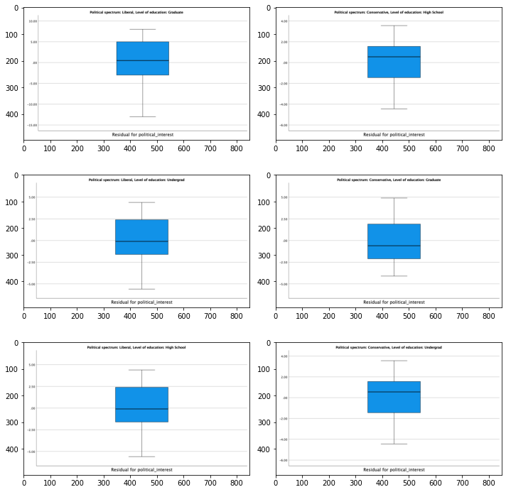

```python
# Vertical 3 x 2
_, axarr = plt.subplots(3, 2, figsize=(10,10)) #two rows and #3 columns
curr_col = 0
for index in range(len(images)):
     # fetch the url as a file type object, then read the image
        image_path = plt.imread(images[index])

        # find the row by taking the current index modulo 2
        row = index % 3

        # plot on relevant subplot
        axarr[row,curr_col].imshow(image_path)
        if row == 2:
            # increment row
            curr_col += 1

plt.tight_layout()
plt.show()
```

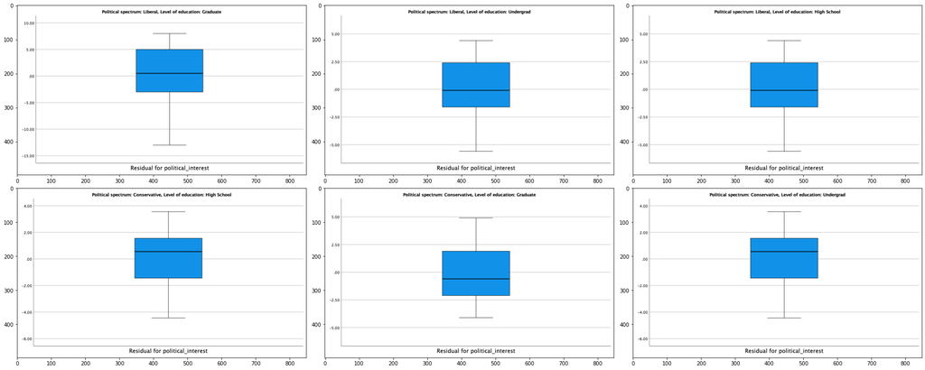

```python
# horizontal 2 x 3 grid
# This method uses the same principle as above, but we are useing three columns and two rows
# the code is adjusted to increment the row and plot images from left to right.
_, axarr = plt.subplots(2, 3, figsize=(25,10)) #two rows and #3 columns
curr_row = 0
for index in range(len(images)):
     # fetch the url as a file type object, then read the image
        image_path = plt.imread(images[index])

        # find the row by taking the current index modulo 2
        col = index % 3

        # plot on relevant subplot
        axarr[curr_row,col].imshow(image_path)
        if col == 2:
            # increment row
            curr_row += 1

plt.tight_layout()
plt.show()
```

```python
#post_dir = os.path.dirname(os.path.dirname(os.getcwd())) # points at
post_dir = os.chdir('..')
post_dir = os.getcwd()
```

```python
html_subdir = 'images/static/images/imread' # will direct to html images from blog post
html_rf_path =  os.path.join(post_dir, html_subdir) # filepath for images that will be displayed by html
html_files = os.listdir(html_rf_path) # this is to ensure images are displayed in blog post.
html_subdir_ = 'projects/images/static/images/imread' # will direct to html images from blog post
```

## Prepare a list of filepaths to images using a list comprehension

- will do this for the images we will display using HTML related methods
- this will return a relative file path from the actual blog post directory

```python
# this method uses a list comprehension to generate a list of relative filepaths with png only
html_images = [os.path.join(html_subdir_, file) for file in html_files if file.endswith('png')]
```

# Display a grid of images using IPython.display HTML and Image.

**iPython.display**

- Contains 23 classes and 16 functions to render objects in iPython and includes images, video, audio, html, and images.
- Additional information can be found here: [Documentation as of date of this post](https://ipython.readthedocs.io/en/stable/api/generated/IPython.display.html).
- The following methods will illustrate how to display multiple images in a cell using IPython HTML and display.
- This code will utilize HTML and fancier output formatting to use formatted string literals (where you can include your file path variable.
- More information on fancier output formatting can be found here: [Documentation](https://docs.python.org/3/tutorial/inputoutput.html).
- This method also relies on using html table code, which can be described here: [HTML Table documentation](https://www.w3schools.com/html/html_tables.asp).
- The only draw back is how chunky the code can get with html table code.

```python
# Display using hTML for four images
from IPython.display import HTML, display
display(HTML(f"<table><tr><td><img src={html_images[0]}></td><td><img src={html_images[1]}></td></tr><td><img src={html_images[2]}></td><td><img src={html_images[3]}></td></tr></table>"))
```

[output not shown]

# Display a grid of images using iPyPlot

**ipyplot**

- Simple package that leverages IPython and HTML for more efficient, reach and interactive plotting of images in Jupyter Notebooks.
- Additional information can be found here: [Documentation as of date of this post](https://pypi.org/project/ipyplot/).
- You will need to install this package.
- iPyPlot is a quick and efficient method for plotting images inside a Python Notebook cell and combines HTML and iPython for you. It contains a few image display objects, but in this case, we will only demonstrate how to display a collection of images.
- Why is this an improvement? It doesn't require you to hard code the html table code or use a for loop, subplots, or any other code to render your grid. The only downfall is that it display the local or remote image file url, but this isn't a big deal.

**Process**

- Import ipyplot.
- Prepare a list of labels, and they should be a sequence of strings or int.
- Prepare a list of images. The list should be a sequence of either strings (local or remote image file URLS), PIL.Image objects or numpy.ndarray objects representing images.
- Use this code: `ipyplot.plot_images(images, labels, img_width=width)`.
- the width is an integer.

```python
import ipyplot
```

```python
labels = ["Label 1", "Label 2", "Label 3", "Label 4", "Label 5", "Label 6"]
ipyplot.plot_images(html_images, labels, img_width=300)
```

show html

Label 1

projects/images/static/images/imread/spss4f.png

[figure not shown]

Label 2

projects/images/static/images/imread/spss4e.png

[figure not shown]

Label 3

projects/images/static/images/imread/spss4d.png

[figure not shown]

Label 4

projects/images/static/images/imread/spss4a.png

[figure not shown]

Label 5

projects/images/static/images/imread/spss4c.png

[figure not shown]

Label 6

projects/images/static/images/imread/spss4b.png

[figure not shown]